# R Notebook

```r
library(data.table)
```

```r
train <- fread("../Data/train.csv",header = T,stringsAsFactors = T)
```

```
Read 44.5% of 404290 rows
Read 404290 rows and 6 (of 6) columns from 0.059 GB file in 00:00:03
```

```r
test <- fread("../Data/test.csv",header = T,stringsAsFactors = T)
```

```
Read 17.9% of 2345805 rows
Read 24.3% of 2345805 rows
Read 54.6% of 2345805 rows
Read 66.9% of 2345805 rows
Read 69.1% of 2345805 rows
Read 95.1% of 2345805 rows
Read 2345796 rows and 3 (of 3) columns from 0.292 GB file in 00:00:16
```

### Summary

```r
str(test)
```

```
Classes ‘data.table’ and 'data.frame':  2345796 obs. of  3 variables:
 $ test_id  : int  0 1 2 3 4 5 6 7 8 9 ...
 $ question1: Factor w/ 2211009 levels ""," A tank 10m long and 5m wide has water up to a depth of 3m. What is the total area of the wet surface?",..: 561645 1018842 1278606 1906382 224701 246497 304484 50279 1222105 6227 ...
 $ question2: Factor w/ 2227400 levels ""," A tank 10m long and 5m wide has water up to a depth of 3m. What is the total area of the wet surface?",..: 2067387 649789 1792877 1382377 702494 730517 308097 718739 1170567 75726 ...
 - attr(*, ".internal.selfref")=<externalptr>
```

### Change data types

```r
train$question1 <- as.character(train$question1)
train$question2 <- as.character(train$question2)
test$question1 <- as.character(test$question1)
test$question2 <- as.character(test$question2)
```

## EDA on train data

```r
summary(train)
```

```
       id              qid1             qid2         question1          question2         is_duplicate
 0      :     1   8461   :    50   30782  :   120   Length:404290      Length:404290      0:255027
 1      :     1   14110  :    48   2559   :   115   Class :character   Class :character   1:149263
 10     :     1   1749   :    47   4044   :   100   Mode  :character   Mode  :character
 100    :     1   20628  :    47   2561   :    71
 1000   :     1   25984  :    47   17978  :    66
 10000  :     1   4951   :    46   14376  :    59
 (Other):404284   (Other):404005   (Other):403759
```

No NAs in any of the columns. The question with qid1==8461 is repeating 50 times.

```r
sum(table(train$qid1)>=3)/nrow(train)
```

```
[1] 0.05182666
```

~5% of the questions are repeated more than 3 times. Maybe they can be marked as duplicates.

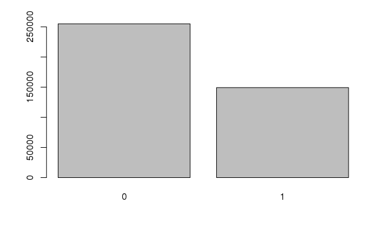

Non duplicates are more than duplicates. Makes sense.

Are the questions which are repeated more than 3 times, duplicates or not duplicaes?

```r
table(train$qid1)[table(train$qid1) >10]
```

```
100212 100238  10024  10061  10098  10120 101252 101402 101428 101854  10216  10234 102780  10280 102817 102866
    14     14     15     11     12     15     15     15     11     11     16     20     11     21     32     13
 10311  10321  10322  10329  10330  10359  10370  10382  10409  10433 104333  10437 104629  10472  10473 104901
    18     19     26     28     27     21     12     23     13     36     13     20     26     25     17     12
105062  10523  10524 105419  10565  10566 105692  10591  10615   1062 106489  10671 106889  10693  10695  10720
    11     11     12     15     14     22     14     11     13     27     16     26     13     25     16     15
 10730  10796 107987  10804  10819 108331  10859  10907 109131 109191 109342 109596   1100  11012  11034  11091
    12     14     11     16     12     11     36     11     12     13     12     14     19     14     11     27
111364  11139  11167  11168 111726  11174   1120  11212  11233  11286  11321  11342 113473  11348 113583 113631
    16     13     25     23     15     12     15     20     17     15     15     23     11     15     14     20
113639  11392  11396  11397  11408  11434  11442 114426  11443 114739  11476 114804 115113 115373  11588  11591
    11     25     19     25     20     17     19     14     13     17     13     20     12     11     30     11
 11600  11605 116087  11616 116357  11638 116443 116561  11698  11708 117180 117292 117473 117766   1178  11804
    12     17     13     11     12     23     11     15     14     12     16     12     13     12     20     25
  1182   1183 118573  11881  12017   1202 120209  12062  12139   1214 121583  12214  12241 122585  12263  12303
```

[output cut: 112 more lines]

What about qid2 ?

```r
hist(table(train$qid2)[table(train$qid2)>=3],breaks = 20,probability = T)
sum(table(train$qid2)>=3)/nrow(train)
```

[figure not shown]

[figure not shown]

Shorter questions are slightly more likely to be duplicate. But, doesn’t look like it brings strong separateability. Still, could be one of the features in the classification model.

```r
train$nchar1 <- nchar(train$question1)
train$nchar2 <- nchar(train$question2)
```